# INVESTIGATE A DATASET ASSIGNMENT

## Project: Investigate a Dataset - [No Show Appointment]

## Dataset Description

This dataset collects information from 100k medical appointments in Brazil and is focused on the question of whether or not patients show up for their appointment. A number of characteristics about the patient are included in each row.

'PatientId' Unique Identifier for each patient in the dataset 'AppointmentId' appointment identification for each patient ‘ScheduledDay’ tells us on what day the patient set up their appointment. ‘Neighborhood’ indicates the location of the hospital. ‘Scholarship’ indicates whether or not the patient is enrolled in Brasilian welfare program Bolsa Família. 'No-Show'indicates whether or not the patient shows up or not ‘No’ if the patient showed up to their appointment ‘Yes’ if they did not show up.

The dataset will be analyzed to determine what factors are important to predict if a patient will show up for their scheduled appointment?

## Questions for Analysis

(1) What is the gender distribbution of patients who missed their appointments?

(2) Was there a relationship between the age distribution of the patients and their tendency to show up?

(3) How did receiving sms reminders or being a recipient of the bolsa familia scholarship have impact on the availability of the patient for their appointment

(4) How did the condition in terms of being Hipertensive,Diabetic, handicapped or being an alcoholic affect their availability for appointment.

(5) What are the top 10 neighbourhoods in terms of both show up and absence for appointments

```python
#Importing packages that will be used during the course of the anlalysis
import pandas as pd
import numpy as np
import matplotlib.pyplot as plt
import seaborn as sns
%matplotlib inline
```

## General Properties

```python
# Loading data and printing out a few lines using the .head() function in the pandas library
no_show_data = pd.read_csv('noshowappointments-kagglev2-may-2016.csv')
no_show_data.head()
```

|  | PatientId | AppointmentID | Gender | ScheduledDay | AppointmentDay | Age | Neighbourhood | Scholarship | Hipertension | Diabetes | Alcoholism | Handcap | SMS_received | No-show |
| --- | --- | --- | --- | --- | --- | --- | --- | --- | --- | --- | --- | --- | --- | --- |
| 0 | 2.987250e+13 | 5642903 | F | 2016-04-29T18:38:08Z | 2016-04-29T00:00:00Z | 62 | JARDIM DA PENHA | 0 | 1 | 0 | 0 | 0 | 0 | No |
| 1 | 5.589980e+14 | 5642503 | M | 2016-04-29T16:08:27Z | 2016-04-29T00:00:00Z | 56 | JARDIM DA PENHA | 0 | 0 | 0 | 0 | 0 | 0 | No |
| 2 | 4.262960e+12 | 5642549 | F | 2016-04-29T16:19:04Z | 2016-04-29T00:00:00Z | 62 | MATA DA PRAIA | 0 | 0 | 0 | 0 | 0 | 0 | No |
| 3 | 8.679510e+11 | 5642828 | F | 2016-04-29T17:29:31Z | 2016-04-29T00:00:00Z | 8 | PONTAL DE CAMBURI | 0 | 0 | 0 | 0 | 0 | 0 | No |
| 4 | 8.841190e+12 | 5642494 | F | 2016-04-29T16:07:23Z | 2016-04-29T00:00:00Z | 56 | JARDIM DA PENHA | 0 | 1 | 1 | 0 | 0 | 0 | No |

```python
# To display the number of rows and column in the dataset
no_show_data.shape
```

```
(110527, 14)
```

```python
#general information of the columns to know the number of non-null values and datatypes
no_show_data.info()
```

```
<class 'pandas.core.frame.DataFrame'>
RangeIndex: 110527 entries, 0 to 110526
Data columns (total 14 columns):
 #   Column          Non-Null Count   Dtype
---  ------          --------------   -----
 0   PatientId       110527 non-null  float64
 1   AppointmentID   110527 non-null  int64
 2   Gender          110527 non-null  object
 3   ScheduledDay    110527 non-null  object
 4   AppointmentDay  110527 non-null  object
 5   Age             110527 non-null  int64
 6   Neighbourhood   110527 non-null  object
 7   Scholarship     110527 non-null  int64
 8   Hipertension    110527 non-null  int64
 9   Diabetes        110527 non-null  int64
 10  Alcoholism      110527 non-null  int64
 11  Handcap         110527 non-null  int64
 12  SMS_received    110527 non-null  int64
 13  No-show         110527 non-null  object
dtypes: float64(1), int64(8), object(5)
memory usage: 9.7+ MB
```

```python
#to show some quick statistics on the dataset
no_show_data.describe()
```

|  | PatientId | AppointmentID | Age | Scholarship | Hipertension | Diabetes | Alcoholism | Handcap | SMS_received |
| --- | --- | --- | --- | --- | --- | --- | --- | --- | --- |
| count | 1.105270e+05 | 1.105270e+05 | 110527.000000 | 110527.000000 | 110527.000000 | 110527.000000 | 110527.000000 | 110527.000000 | 110527.000000 |
| mean | 1.474963e+14 | 5.675305e+06 | 37.088874 | 0.098266 | 0.197246 | 0.071865 | 0.030400 | 0.022248 | 0.321026 |
| std | 2.560949e+14 | 7.129575e+04 | 23.110205 | 0.297675 | 0.397921 | 0.258265 | 0.171686 | 0.161543 | 0.466873 |
| min | 3.920000e+04 | 5.030230e+06 | -1.000000 | 0.000000 | 0.000000 | 0.000000 | 0.000000 | 0.000000 | 0.000000 |
| 25% | 4.172615e+12 | 5.640286e+06 | 18.000000 | 0.000000 | 0.000000 | 0.000000 | 0.000000 | 0.000000 | 0.000000 |
| 50% | 3.173180e+13 | 5.680573e+06 | 37.000000 | 0.000000 | 0.000000 | 0.000000 | 0.000000 | 0.000000 | 0.000000 |
| 75% | 9.439170e+13 | 5.725524e+06 | 55.000000 | 0.000000 | 0.000000 | 0.000000 | 0.000000 | 0.000000 | 1.000000 |
| max | 9.999820e+14 | 5.790484e+06 | 115.000000 | 1.000000 | 1.000000 | 1.000000 | 1.000000 | 4.000000 | 1.000000 |

```python
# to display the datatypes in each of the available 14 columns of the dataset
no_show_data.dtypes
```

```
PatientId         float64
AppointmentID       int64
Gender             object
ScheduledDay       object
AppointmentDay     object
Age                 int64
Neighbourhood      object
Scholarship         int64
Hipertension        int64
Diabetes            int64
Alcoholism          int64
Handcap             int64
SMS_received        int64
No-show            object
dtype: object
```

```python
#to display the names of the columns in the dataset
no_show_data.columns
```

```
Index(['PatientId', 'AppointmentID', 'Gender', 'ScheduledDay',
       'AppointmentDay', 'Age', 'Neighbourhood', 'Scholarship', 'Hipertension',
       'Diabetes', 'Alcoholism', 'Handcap', 'SMS_received', 'No-show'],
      dtype='object')
```

```python
#to display the number of unique values in each of the available 14 columns
no_show_data.nunique()
```

```
PatientId          61744
AppointmentID     110527
Gender                 2
ScheduledDay      103549
AppointmentDay        27
Age                  104
Neighbourhood         81
Scholarship            2
Hipertension           2
Diabetes               2
Alcoholism             2
Handcap                5
SMS_received           2
No-show                2
dtype: int64
```

```python
#to display the number duplicated records in the datset
no_show_data.duplicated().sum()
```

```
0
```

```python
#to display the number of rows with empty values in the dataset
no_show_data.isnull().sum()
```

```
PatientId         0
AppointmentID     0
Gender            0
ScheduledDay      0
AppointmentDay    0
Age               0
Neighbourhood     0
Scholarship       0
Hipertension      0
Diabetes          0
Alcoholism        0
Handcap           0
SMS_received      0
No-show           0
dtype: int64
```

## Data Cleaning

```python
# to reveal the numer of duplicated patient IDs
no_show_data['PatientId'].duplicated().sum()
```

```
48783
```

```python
#to drop the duplicated patient IDs and keeping the first instance while at it
no_show_data = no_show_data.drop_duplicates(subset =['PatientId'], keep = 'first')
#connfirming the shape of the dataset after dropping the duplicates
no_show_data.shape
```

```
(61744, 14)
```

```python
#removing ages less than 0
no_show_data[no_show_data['Age']<0]
no_show_data.drop(no_show_data[no_show_data['Age']<0].index, inplace = True)
```

```python
#confirming all ages less than 0 has been removed
no_show_data[no_show_data['Age'] < 0]
```

|  | PatientId | AppointmentID | Gender | ScheduledDay | AppointmentDay | Age | Neighbourhood | Scholarship | Hipertension | Diabetes | Alcoholism | Handcap | SMS_received | No-show |
| --- | --- | --- | --- | --- | --- | --- | --- | --- | --- | --- | --- | --- | --- | --- |

## Exploratory Analysis

```python
#Categorizing the patients based on their appointment show up status
df_show = no_show_data[no_show_data['No-show'] == 'No']
df_absent = no_show_data[no_show_data['No-show'] == 'Yes']
```

```python
#Confirming that our categorization worked
df_show.head(3)
df_absent.head(3)
```

|  | PatientId | AppointmentID | Gender | ScheduledDay | AppointmentDay | Age | Neighbourhood | Scholarship | Hipertension | Diabetes | Alcoholism | Handcap | SMS_received | No-show |
| --- | --- | --- | --- | --- | --- | --- | --- | --- | --- | --- | --- | --- | --- | --- |
| 6 | 7.336880e+14 | 5630279 | F | 2016-04-27T15:05:12Z | 2016-04-29T00:00:00Z | 23 | GOIABEIRAS | 0 | 0 | 0 | 0 | 0 | 0 | Yes |
| 7 | 3.449830e+12 | 5630575 | F | 2016-04-27T15:39:58Z | 2016-04-29T00:00:00Z | 39 | GOIABEIRAS | 0 | 0 | 0 | 0 | 0 | 0 | Yes |
| 11 | 7.542950e+12 | 5620163 | M | 2016-04-26T08:44:12Z | 2016-04-29T00:00:00Z | 29 | NOVA PALESTINA | 0 | 0 | 0 | 0 | 0 | 1 | Yes |

### Question 1 : What is the gender distribbution of patients who missed their appointments?

```python
#displaying the result on a plot
#fig, ax = plt.subplots(figsize = (8,6))
#ax.hist(df_show['Gender'], alpha=0.9, label='Show')
#ax.hist(df_absent['Gender'], alpha=0.9, label='Absent')
#ax.set_title = ('Gender distribution of appointment show up')
#ax.set_xlabel('Gender')
#ax.set_ylabel('Count')
#ax.legend(loc='upper center')
def plot (xlabel, ylabel, title):
    ax.hist(df_show['Gender'], alpha=0.9, label='Show')
    ax.hist(df_absent['Gender'], alpha=0.9, label='Absent')
    ax.set_xlabel('Gender')
    ax.set_ylabel('Count')
    ax.set_title = ('Gender distribution of appointment show up')
    ax.legend(loc='upper center')
    fig, ax = plt.subplots(figsize = (8,6))
    ax.draw()


plot
```

[output not shown]

```
<function __main__.plot(xlabel, ylabel, title)>
```

### Question 2: Was there a relationship between the age distribution of the patients and their tendency to show up?

```python
# creating a new column 'age group' in the dataframe
no_show_data.loc[no_show_data['Age']<=12, 'Age_group'] = 'Young Children'
no_show_data.loc[no_show_data['Age'].between(13,19), 'Age_group'] = 'Teenagers'
no_show_data.loc[no_show_data['Age'].between(20,30), 'Age_group'] = 'Young Adult'
no_show_data.loc[no_show_data['Age'].between(31,60), 'Age_group'] = 'Older Adult'
no_show_data.loc[no_show_data['Age']>60, 'Age_group'] = 'Aged Persons'
```

```python
#confirming that the 'age group' column has been added to the dataframe.
no_show_data['Age_group'].unique()
```

```
array(['Aged Persons', 'Older Adult', 'Young Children', 'Young Adult',
       'Teenagers'], dtype=object)
```

```python
# creating a new column 'show_up_status' in the dataframe
no_show_data.loc[no_show_data['No-show'] == 'No', 'show_up_status'] = 'show up'
no_show_data.loc[no_show_data['No-show'] == 'Yes', 'show_up_status'] = 'Absent'
```

```python
#confirming that the 'show_up_status' column has been added to the dataframe.
no_show_data['show_up_status'].unique()
```

```
array(['show up', 'Absent'], dtype=object)
```

```python
#displaying the value counts of all the age groups
no_show_data['Age_group'].value_counts()
```

```
Older Adult       24315
Young Children    12576
Aged Persons      11234
Young Adult        8339
Teenagers          5279
Name: Age_group, dtype: int64
```

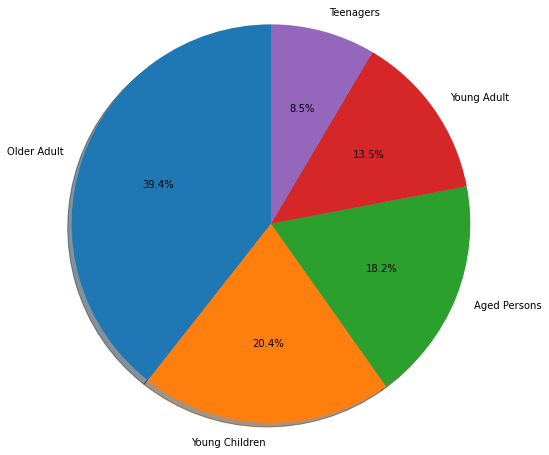

```python
#visualizing the percetage of the entire of the total vaulue counts each age group accounts for
labels = 'Older Adult', 'Young Children', 'Aged Persons', 'Young Adult', 'Teenagers'
sizes = [39.4, 20.4, 18.2, 13.5, 8.5]
explode = (0, 0, 0, 0, 0)

fig1, ax1 = plt.subplots(figsize=(8,8))
ax1.pie(sizes, explode=explode, labels=labels, autopct='%1.1f%%',
        shadow=True, startangle=90)
ax1.axis('equal')  # Equal aspect ratio ensures that pie is drawn as a circle.

plt.show()
```

#### The pier chart above is a visualization result after slicing the patients into age groups. We can deduce from it that older adults i.e patients between the ages of 31 & 60 hold the highest proportion of our sample dataset.

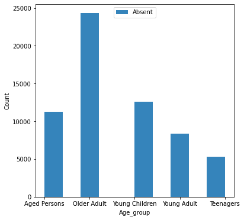

```python
fig, ax = plt.subplots(figsize = (6,6))
ax.hist(no_show_data['Age_group'], alpha=0.9, label='Absent')
ax.set_title = ('Age_group distribution of appointment show up')
ax.set_xlabel('Age_group')
ax.set_ylabel('Count')
ax.legend(loc='upper center')
```

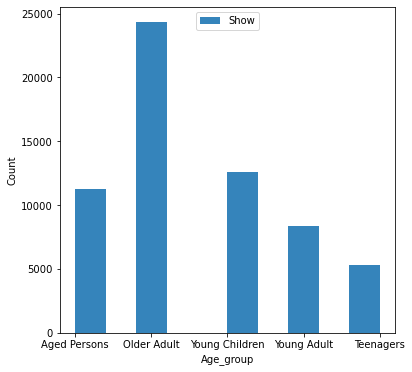

```python
fig, ax = plt.subplots(figsize = (6,6))
ax.hist(no_show_data['Age_group'], alpha=0.9, label='Show')
ax.set_title = ('Age_group distribution of appointment show up')
ax.set_xlabel('Age_group')
ax.set_ylabel('Count')
ax.legend(loc='upper center')
```

### Question 3 : How did receiving sms reminders or being a recipient of the bolsa familia scholarship have impact on the availability of the patient for their appointment?

#### For scholarship

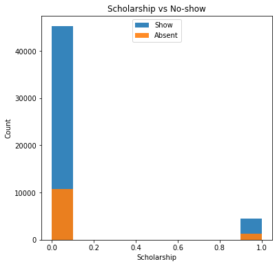

```python
fig,ax=plt.subplots(figsize=(6,6))
ax.hist(df_show['Scholarship'], alpha=0.9, label='Show')
ax.hist(df_absent['Scholarship'], alpha=0.9, label='Absent')
ax.set_title('Scholarship vs No-show')
ax.set_xlabel('Scholarship')
ax.set_ylabel('Count')
ax.legend(loc='upper center')
```

#### The visualization above shows that patients who did not recieve the bolsia familia scholarship showed up more than those eho recived. this implies that there is no particular relationship betwen the two variables because ideally people by nature take advantage of services that comes with little or no costs at all.

#### For sms alert

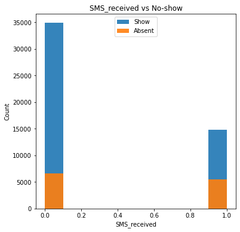

```python
fig,ax=plt.subplots(figsize=(6,6))
ax.hist(df_show['SMS_received'], alpha=0.9, label='Show')
ax.hist(df_absent['SMS_received'], alpha=0.9, label='Absent')
ax.set_title('SMS_received vs No-show')
ax.set_xlabel('SMS_received')
ax.set_ylabel('Count')
ax.legend(loc='upper center')
```

#### The visualization above shows that patients who did not recieve sms reminders had more show up rates compared to those recived once( which is the highest number of sms sent by the way) this implies a negative correlation.

## Question 4: How did the condition in terms of being Hipertensive,Diabetic, handicapped or being an alcoholic affect their availability for appointment.

```python
#defining a function to show a correlation wkithe types of ailments and the appointment show up status
def correlating_columns(disease, title):
    fig, ax = plt.subplots(figsize=(6,6))
    ax.hist(df_show[disease], alpha=0.9, label='Show')
    ax.hist(df_absent[disease], alpha=0.9, label='Absent')
    ax.set_title(title)
    ax.set_xlabel(disease)
    ax.set_ylabel('Count')
    ax.legend(loc='upper center')
```

#### For diabetes

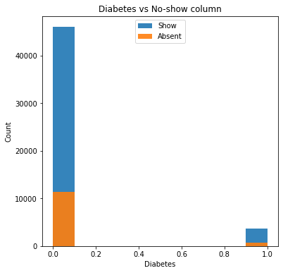

```python
#displaying the realtionship between diabetes diagnosis and attendance using the defined function above
correlating_columns("Diabetes", "Diabetes vs No-show column")
```

#### For Hypertension

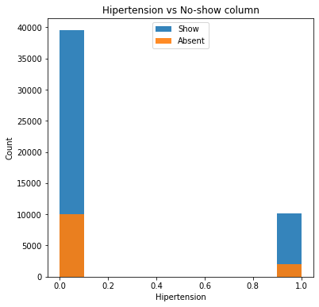

```python
#displaying the realtionship between Hypertension diagnosis and attendance using the defined function above
correlating_columns("Hipertension", "Hipertension vs No-show column")
```

#### The histogram above depicts that there is a negative correlation between the two variables 'hipertension' and 'no-show'

#### For handicap

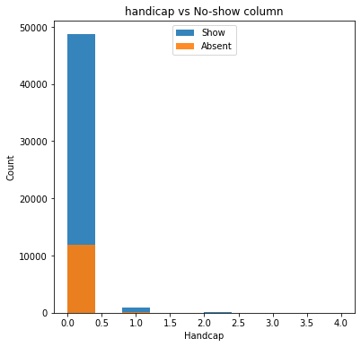

```python
#displaying the realtionship between handicap diagnosis and attendance using the defined function above
correlating_columns("Handcap", "handicap vs No-show column")
```

#### For Alcohol

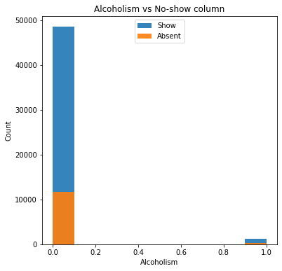

```python
#displaying the realtionship between Alcohol diagnosis and attendance using the defined function above
correlating_columns("Alcoholism", "Alcoholism vs No-show column")
```

### Question 5 What are the top 10 neighbourhoods in terms of both show up and absence for appointments

#### For show up

```python
#displaying the top 10 Neighbourhood by show up using the value_counts() and .head() functions in pandas
df_show['Neighbourhood'].value_counts().head(10)
```

```
JARDIM CAMBURI     3374
MARIA ORTIZ        2623
JARDIM DA PENHA    1984
RESISTÊNCIA        1890
ITARARÉ            1596
TABUAZEIRO         1544
SANTA MARTHA       1487
CENTRO             1471
SANTO ANTÔNIO      1387
BONFIM             1269
Name: Neighbourhood, dtype: int64
```

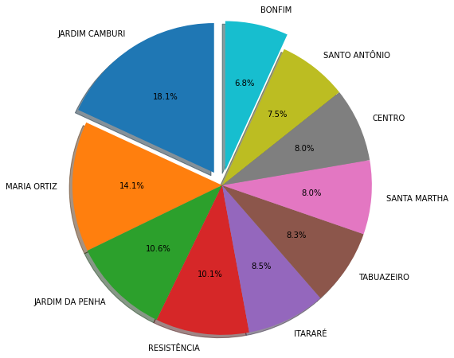

```python
#visualizazing the putcome with the aid of percentage based pie chart
labels = 'JARDIM CAMBURI', 'MARIA ORTIZ', 'JARDIM DA PENHA', 'RESISTÊNCIA', 'ITARARÉ', 'TABUAZEIRO', 'SANTA MARTHA', 'CENTRO', 'SANTO ANTÔNIO', 'BONFIM'
sizes = [18.1, 14.1, 10.6, 10.1, 8.5, 8.3, 8.0, 8.0, 7.5, 6.8]
explode = (0.1, 0, 0, 0, 0, 0, 0, 0, 0, 0.1)  # "explode" the 1st an last slice (i.e. 'JARDIM CAMBURI ' & 'BONFIM')

fig1, ax1 = plt.subplots(figsize=(8,8))
ax1.pie(sizes, explode=explode, labels=labels, autopct='%1.1f%%',
        shadow=True, startangle=90)
ax1.axis('equal')  # Equal aspect ratio ensures that pie is drawn as a circle.

plt.show()
```